# Pitcher card

# Stephen Kolek

RHP · KC

2026 · 10 G (10 GS) · 837 pitches · May 05 – Jul 02, 2026

Independent portfolio sample by Devin Jenkinson, not affiliated with any club. Every number is computed from public Statcast data.

Three big takeaways

1Watch

The slider is his most-used two-strike pitch.

28% of two-strike pitches · 42 two-strike swings so far

No pitch has 50+ two-strike swings yet, so this card does not name a put-away pitch by miss rate.

2Avoid

Limit the changeup. It is his most damaging pitch.

xRV/100 -0.41 shrunk (raw -1.40) · .385 xwOBAcon · 100 pitches

When behind in the count he throws it 8% of the time; the cutter grades +0.43 there instead.

3Watch

21% chased on 109 out-of-zone pitches

Fastball height splits are too thin to call (76 swings up, 10 down).

Charts

### Movement

The ST finishes 28 in from his FF, with 21 in more glove-side run.

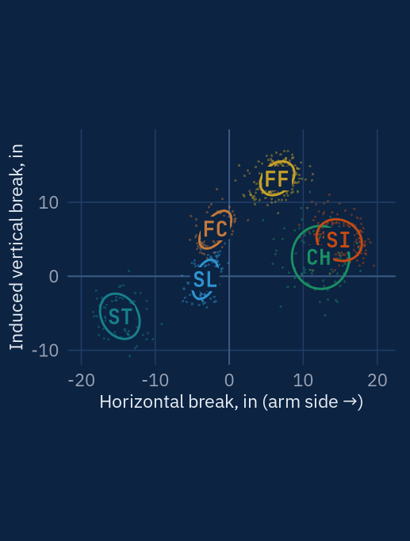

n = 837 pitches. Ellipses hold about 68% of each type; codes sit at the averages.

### Location by count

He throws 62% of pitches in the zone when behind and 43% when ahead.

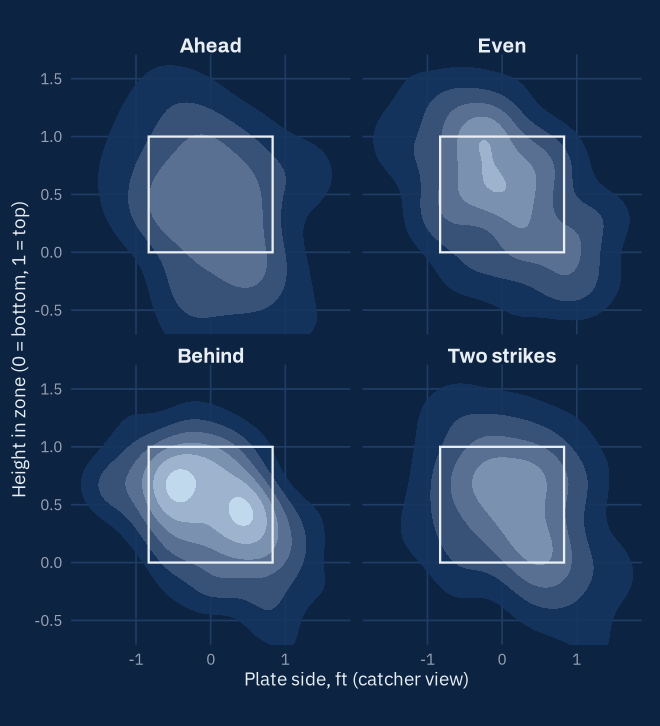

n = 837. Ahead 106 · even 307 · behind 208 · two strikes 216 pitches. Box = rule-book zone.

### Put-away

The SL is 28% of two-strike pitches vs 16% overall.

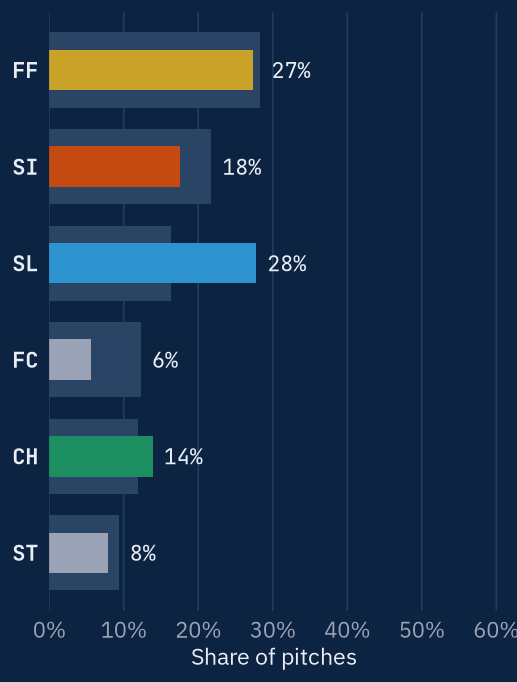

Two-strike n: SL 60, FF 59, SI 38, CH 30, ST 17, FC 12. Grey bars = overall usage; wh = whiffs per swing (shown with 50+ swings).

### Arsenal

| Pitch | # | Use | Velo | IVB | HB | VAA | Whiff | Chase | xwOBAcon | xRV/100 | Stuff+ |
| --- | --- | --- | --- | --- | --- | --- | --- | --- | --- | --- | --- |
| 4-Seam (FF) | 237 | 28% | 94.2 | 13.2 | +6.4 | -4.5 | 19% | 21% | .276 | +0.11 | 82 |
| Sinker (SI) | 182 | 22% | 93.7 | 5.0 | +14.8 | -5.8 | 6% | 23% | .301 | +0.42 | 97 |
| Slider (SL) | 137 | 16% | 85.6 | -0.4 | -3.2 | -7.4 | 43% | 46% | .380 | -0.07 | 98 |
| Cutter (FC) | 103 | 12% | 90.3 | 6.5 | -1.9 | -5.8 | 21% | 22% | .332 | +0.43 | 100 |
| Changeup (CH) | 100 | 12% | 87.1 | 2.6 | +12.1 | -6.9 | 16% | 33% | .385 | -0.41 | 94 |
| Sweeper (ST) | 78 | 9% | 79.9 | -5.4 | -14.7 | -8.0 | 9% | 7% | .384 | -0.10 | 97 |

IVB / HB in inches (HB + = arm side). VAA in degrees at the front of the plate. xRV/100 = expected run value per 100 pitches, pitcher’s view, shrunk with a 250-pitch prior. Stuff+ = this project’s shape-only model (100 = MLB average, 10 = 1 SD).

### Vs. batter hand

| Pitch | LHH # | Use | Whiff | xwOBAcon | RHH # | Use | Whiff | xwOBAcon |
| --- | --- | --- | --- | --- | --- | --- | --- | --- |
| FF | 169 | 34% | 17% | .321 | 68 | 20% | – | .212 |
| SI | 53 | 11% | – | .285 | 129 | 37% | 7% | .333 |
| SL | 48 | 10% | – | .204 | 89 | 26% | – | .326 |
| FC | 90 | 18% | – | .249 | 13 | 4% | – | – |
| CH | 95 | 19% | – | .349 | 5 | 1% | – | .321 |
| ST | 35 | 7% | – | .409 | 43 | 12% | – | .347 |

Use = share of pitches to that side. Whiff = whiffs per swing, shown with 50+ swings.